# Homologias, Caracteres e Mensurações

## Medidas Pragmáticas

- Como mensurar atratividade?
- Poderíamos fazer um experimento:

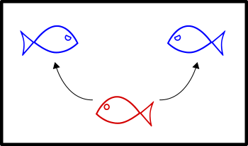

## Medidas Pragmáticas

- Algumas mensurações apenas aproximam o fenômeno de interesse
- Aptidão, este atributo elusivo…
- Nunca se esqueça da distinção entre o fenômeno de interesse e a forma que você usa para representá-lo
- Variável teórica -> Variável operacional

## Porque medir caracteres homólogos?

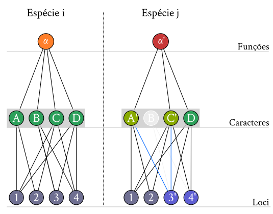

## Quando não medir caracteres homólogos?

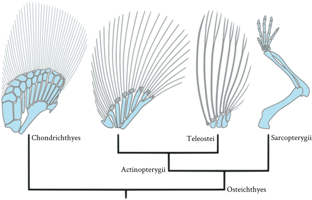

## Quando não medir caracteres homólogos?

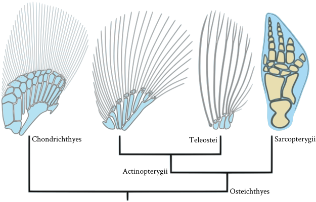

## Uma Situação Ideal

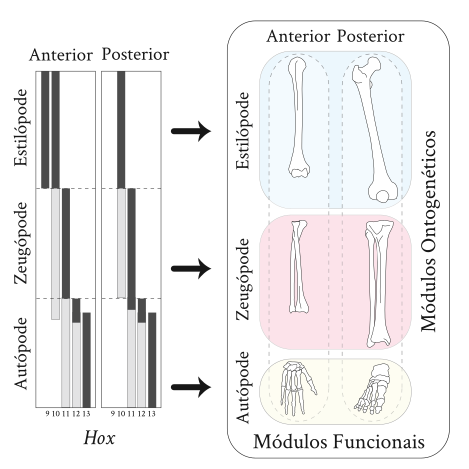

## Morfometria

- *Landmarks*
- Morfometria Tradicional e Geométrica
- Deformações

## *Landmarks*

- Reduzir as relações de homologia entre partes
- Relações de homologias entre pontos
- Tipos de Landmarks
  - Justaposição de tecidos
  - Máximos de curvaturas locais
  - Máximos de curvaturas globais / outros

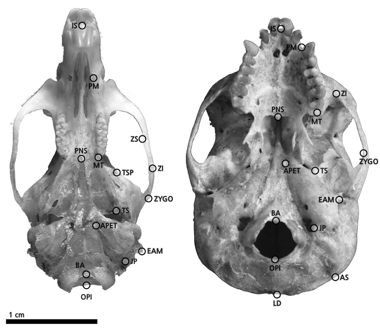

## Distâncias Lineares

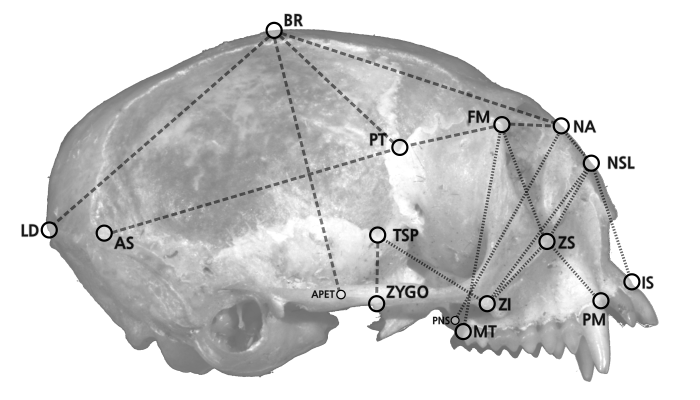

## Coordenadas Cartesianas

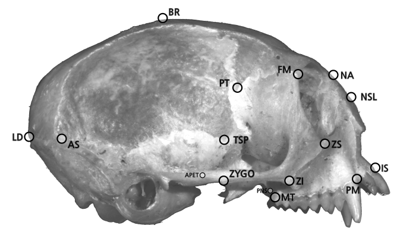

## Análise Generalizada de Procrustes

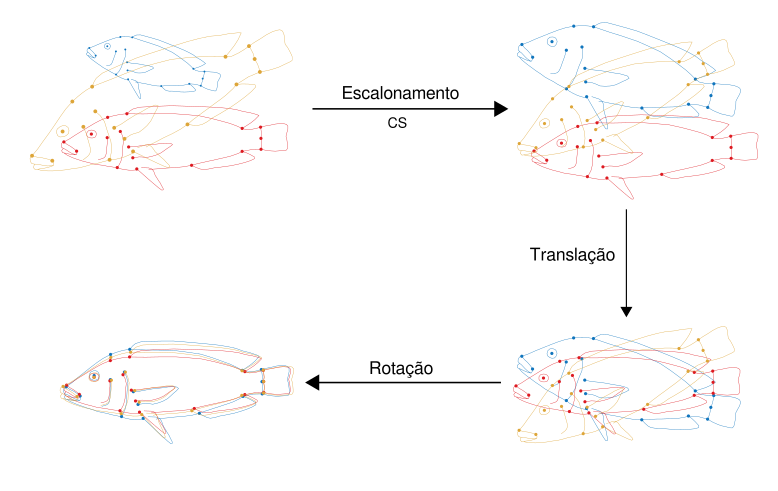

## Deformações

[figure not shown]

## Deformações

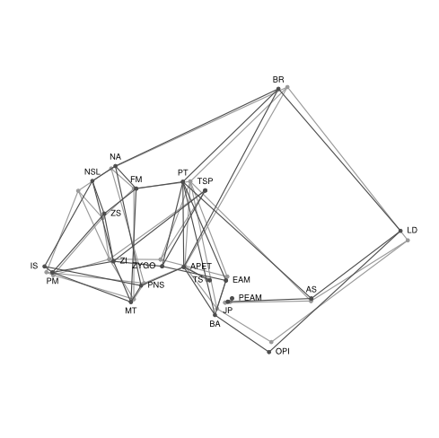

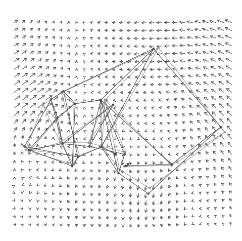